# Industry News

Vol. 67

J.H AHN

2022-05-25

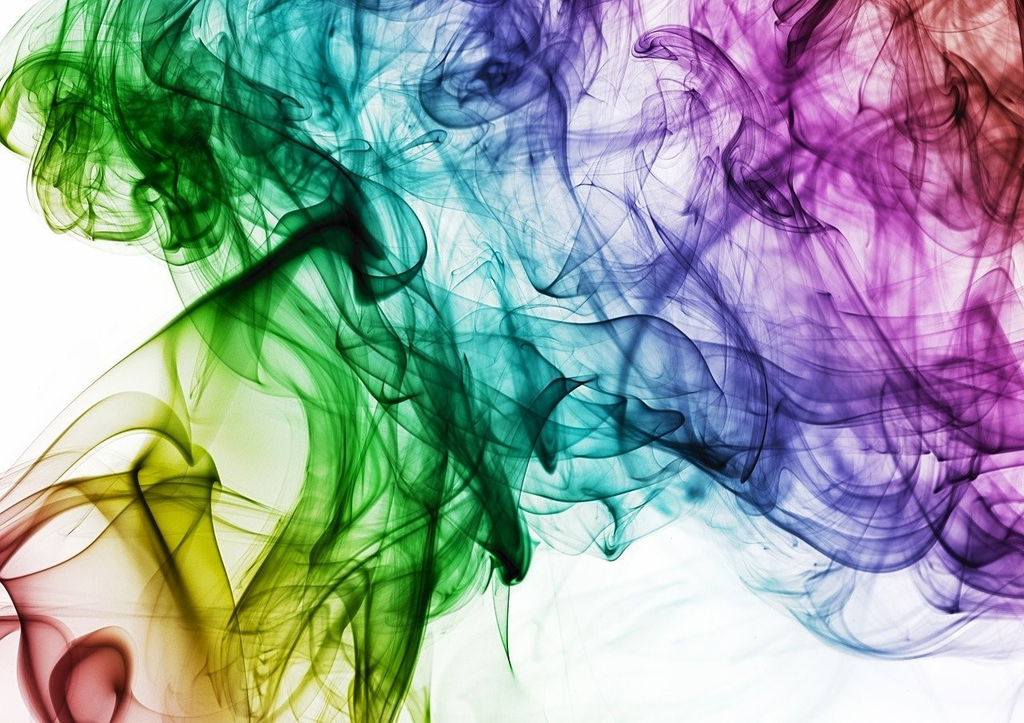

## 잡설

아침 출근길에 바흐의 골드베르크 변주곡을 들었습니다.  
(애플뮤직 큐레이션은 정말 대단한듯…👍)

[figure not shown]

익숙한 곡인데 왠지 울컥했습니다.  
사무실에 오자마자 다른 연주자의 연주를 듣는 중입니다.

참고로 출근길에는 위 표지와 같이 2021년 녹음된 Hannes Minnaar 연주를 들었고,  
지금은 2021년 녹음된 David Fray 연주를 듣고 있습니다.  
전 Hannes Minnaar의 연주에 손을 들어주고 싶습니다.

### 하나 - 5월 SMP가격 하락

몇 년을 갈 것 같이 이야기하던 SMP가 이번 달에 들어오면서 갑자기 떨어졌습니다.  
4월 내내 200원/kWh을 넘게 유지하던 SMP 가격이 140원/kWh 수준까지 떨어졌습니다. 😮  
(물론 작년에 비교하자면 이것도 거의 2배 수준이기 합니다.)

[figure not shown]

이렇게 급격하게 SMP 가격이 떨어진 이유 중 하나는 LNG 가격이 급격하게 떨어졌기 때문입니다.  
계속 더 떨어진다, 아니다, 전문가들의 예측이 엇갈리고 있는데 향후 몇 년간 복합으로 먹고 살아야 하는 우리는 유심히 잘 살펴봐야 할 것 같습니다.

### 둘 - Py-script

이번 주에 웹서비스에 쓰이는 HTML+CSS+JS를 공부했다는 말씀을 드렸는데, 이 세 언어(?)는 사실상 대체 불가능한 존재들이었습니다.  
웹을 하겠다면 무조건 3가지를 배워야 한다는 이야기입니다.

하지만 얼마전 파이썬으로 자바스크립트(JS, JavaScript)를 대신할 수 있는 Py-script가 나오면서 기대감이 엄청나게 올라가고 있습니다.  
어마어마하게 보이는 대체 불가한 자바스크립트는 불과 10일만에 급조된 언어인데다, 당시 선풍적인 인기를 끌고 있던 자바(Java)라는 프로그래밍 언어의 후광을 얻고 싶어 아무 관련도 없지만 이름을 자바스크립트로 한 것이었죠.

어쨌든… 이 자바스크립트를 대체할 수 있는 존재가 몇 주 전 세상에 나온 [Py-script](https://pyscript.net/) 👍 입니다.

[figure not shown]

사실 지금은 부족한 부분도 많고 속도도 느리지만 파이썬 개발자 커뮤니티를 생각해본다면 조만간 자바스크립트를 대체할 수 있을지도 모르겠습니다.

웹서비스를 고민하고 계신다면 Py-script도 한 번 들여다보시기 바랍니다. 👀

## 새로운 소식들

### ‘국내 27번째 원전’ 신한울 1호기 시동

[기사링크](http://www.e2news.com/news/articleView.html?idxno=242283)

국내에서 27번째 건설된 원자력발전소이자 세번째 APR1400(1400MW) 원전인 신한울 1호기가 원자로가 가동을 시작했다는 뉴스입니다.  
원자로에 불을 댕겼다는 표현을 하니 뭔가 조금 낯서네요.

[figure not shown]

뭐… 할 말은 많지만 짧게 가겠습니다.

### Siemens Energy Makes $4.3 Billion Gamesa Takeover Offer

[기사링크](https://www.bloomberg.com/news/articles/2022-05-21/siemens-energy-to-offer-18-05-euros-per-share-in-gamesa-takeover)

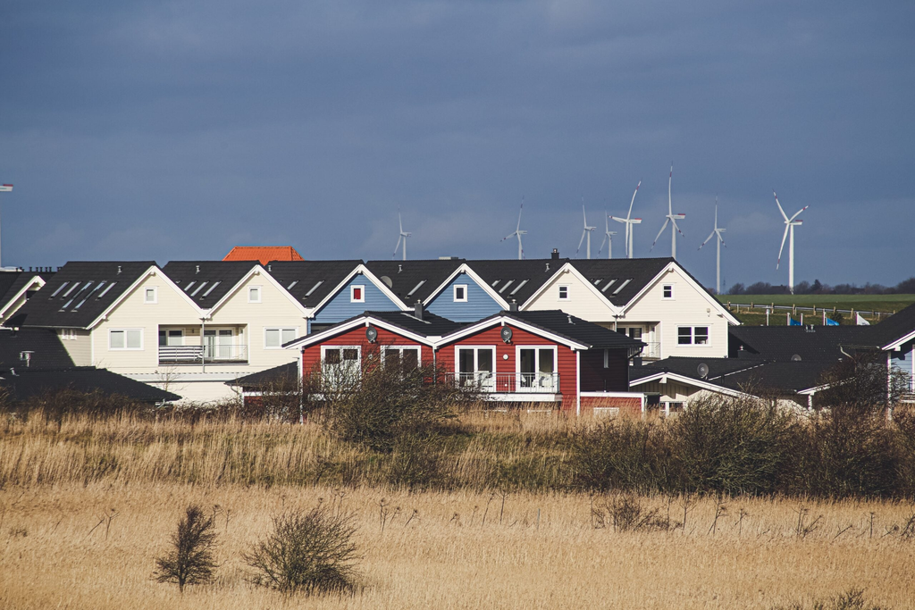

Siemens는 Gamesa 주식을 완전히 인수 한 후 상장폐지 할 예정이며, 이 때문에 Gamesa 주가는 지난 주에만 18%나 상승했습니다.  
어찌되었건 Siemens는 완전체❓가 되었고 향후 통합 시너지 효과(공급망 및 물류비용, 연구개발 및 관리 비용 절감)로 3억 유로를 절감할 수 있을 것으로 기대하고 있다고 합니다.

### How robots can build offshore wind turbines faster

[기사링크](https://www.luxtimes.lu/en/business-finance/how-robots-can-build-offshore-wind-turbines-faster-628a41f8de135b9236cc87be)

대한 구조물을 세우려면 잭업 선박으로 알려진 값비싼 선박이 필요합니다.  
이 선박들이 풍력 터빈을 설치할 장소에 도착하면 앵커를 내려 선박을 파도에서 들어올려 앞뒤로 밀리지 않고 설치 작업을 할 수 있도록 합니다.  
이런 일련의 과정이 이상적인 조건에서는 3시간, 조류가 강한 조건에서는 20시간 이상 걸리기도 합니다.  
BloombergNEF에 따르면 앵커를 내려 파도 위로 올릴 필요가 없는 부유 선박은 이런 작업을 50% 단축 시킬 수 있고, 해저에 설치선을 고정시킬 구조물을 함께 가져가지 않아도 되기 때문에 더 많은 터빈 자재를 운반할 수도 있습니다.

이런 장점을 가진 부유 설치선은 흔들리는 바다에 떠서 설치 작업을 해야 하기 때문에 정확한 작업이 어려운데, 이를 위해 유럽 우주국(European Space Agency) 연구원인 André Schiele이 설립한 X-Laboratory에서 개발한 시스템으로 크레인을 원격 제어 하여 시간을 단축할 수 있습니다.

[figure not shown]

Jan De Nul Group은 이 기술을 채택하였고, Les Alizes라는 이름의 첫 번째 선박은 올해 말에 작업에 들어갈 예정이며 지상에 부착하기 위해 장비를 운반해야 하는 유사한 선박보다 3배 더 많은 무게를 실을 수 있습니다.

이 개발품은 2015년 우주 비행사가 국제 우주 정거장에서 조이스틱을 들고 네덜란드의 한 실험실에서 4륜 로봇을 움직였던 기술을 응용할 방법을 찾던 연구원에 의해 이렇게 상용화 되었습니다.

## 전력시장

### Wordcloud for Enerbility

[interactive chart not shown]

### 전력계통

없음

**best regards,**  
**J.H**

**Industry News?**  
매주 전력산업의 새로운 소식과 산업계 동향을 공유하는 뉴스레터입니다.  
Feedback은 언제라도 환영합니다.  
📫 junho.ahn@doosan.com

**END**